# Explore impact of Non Synonymous Filters

C. Savonen for ALSF CCDL

2020

### Summary of Findings:

This was an exploration of how TMB is affected by using nonsynonymous filters. It addresses part 1 of [this OpenPBTA issue](https://github.com/AlexsLemonade/OpenPBTA-analysis/issues/729) As far as the TMB comparisons go, it doesn’t matter if we use `Variant_Classification` filters or not. They are highly correlated no matter what and the same general TCGA to PBTA differences seem to persist.

### Usage

If both `run_caller_consensus_analysis-tcga.sh` and `run_caller_consensus_analysis-pbta.sh` have been run, you can run this command. This will prepare the files needed for this notebook and run this notebook:

```
# bash run_explorations.sh
```

**Table of Contents** *generated with [DocToc](https://github.com/thlorenz/doctoc)*

- Read in the TMB files
  - Read in PBTA data
  - Read in TCGA data
- Does the filter change a participant’s TMB?
  - Plot PBTA data
  - Plot TCGA data
- Are some histologies affected more than others?
- Does the filter affect the TCGA-PBTA comparison change?
- Plot the ratio of the nonfilter/filter tmb
- Plot the TMB plot with no filter data
  - No filter TMB Plot
  - With filter TMB Plot
- Session Info

## Setup

```r
# Magrittr pipe
`%>%` <- dplyr::`%>%`
```

```r
source(file.path("..", "..", "tmb-compare", "util", "cdf-plot-function.R"))
```

```r
dir.create("plots", showWarnings = FALSE)
```

## Read in the TMB files

### Read in PBTA data

Import the tmb calculations that are not filtered by nonsynonymous classifications.

```r
tmb_pbta_no_filter <- data.table::fread(file.path(
  "..",
  "results",
  "no_filter",
  "pbta-snv-mutation-tmb-coding.tsv"
)) %>%
  dplyr::filter(experimental_strategy != "Panel") %>%
  dplyr::mutate(filter = "no filter")
```

Repeat same steps for original tmb calculations (with filter).

```r
tmb_pbta_with_filter <- data.table::fread(file.path(
  "..",
  "results",
  "consensus",
  "pbta-snv-mutation-tmb-coding.tsv"
)) %>%
  dplyr::filter(experimental_strategy != "Panel") %>%
  dplyr::mutate(filter = "filter")
```

Combine the unfilter and filtered data sets into one.

```r
tmb_pbta <- dplyr::inner_join(tmb_pbta_no_filter,
  dplyr::select(tmb_pbta_with_filter, Tumor_Sample_Barcode, tmb),
  by = "Tumor_Sample_Barcode",
  suffix = c("_no_filter", "_filter")
)
```

### Read in TCGA data

Repeat the same steps for the TCGA data.

```r
tmb_tcga_no_filter <- data.table::fread(file.path(
  "..",
  "results",
  "no_filter",
  "tcga-snv-mutation-tmb-coding.tsv"
)) %>%
  dplyr::mutate(filter = "no filter")
```

```r
tmb_tcga_with_filter <- data.table::fread(file.path(
  "..",
  "results",
  "consensus",
  "tcga-snv-mutation-tmb-coding.tsv"
)) %>%
  dplyr::mutate(filter = "filter")
```

Join these together.

```r
tmb_tcga <- dplyr::inner_join(tmb_tcga_no_filter,
  dplyr::select(tmb_tcga_with_filter, Tumor_Sample_Barcode, tmb),
  by = "Tumor_Sample_Barcode",
  suffix = c("_no_filter", "_filter")
)
```

## Does the filter change a participant’s TMB?

### Plot PBTA data

Correlate first with Pearson’s.

```r
cor.test(tmb_pbta$tmb_filter, tmb_pbta$tmb_no_filter)
```

```
    Pearson's product-moment correlation

data:  tmb_pbta$tmb_filter and tmb_pbta$tmb_no_filter
t = 2488.9, df = 934, p-value < 2.2e-16
alternative hypothesis: true correlation is not equal to 0
95 percent confidence interval:
 0.9999143 0.9999337
sample estimates:
      cor
0.9999246
```

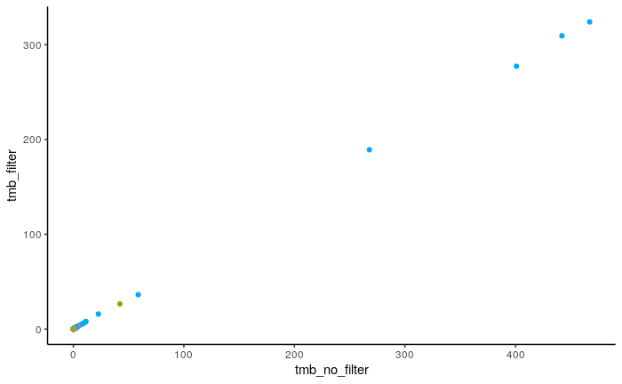

```r
pbta_cor_plot <- ggplot2::ggplot(
  tmb_pbta,
  ggplot2::aes(x = tmb_no_filter, y = tmb_filter, color = short_histology)
) +
  ggplot2::geom_point() +
  ggplot2::theme_classic() +
  ggplot2::theme(legend.position = "none")

pbta_cor_plot
```

This data is very skewed, let’s try a nonparametric correlation.

```r
cor.test(tmb_pbta$tmb_filter, tmb_pbta$tmb_no_filter, method = "spearman")
```

```
Cannot compute exact p-value with ties
```

```
    Spearman's rank correlation rho

data:  tmb_pbta$tmb_filter and tmb_pbta$tmb_no_filter
S = 3031423, p-value < 2.2e-16
alternative hypothesis: true rho is not equal to 0
sample estimates:
      rho
0.9778195
```

Still pretty good.

### Plot TCGA data

```r
cor.test(tmb_tcga$tmb_filter, tmb_tcga$tmb_no_filter)
```

```
    Pearson's product-moment correlation

data:  tmb_tcga$tmb_filter and tmb_tcga$tmb_no_filter
t = 4296.2, df = 316, p-value < 2.2e-16
alternative hypothesis: true correlation is not equal to 0
95 percent confidence interval:
 0.9999893 0.9999931
sample estimates:
      cor
0.9999914
```

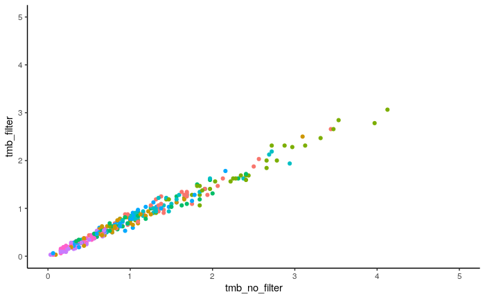

```r
tcga_cor_plot <- ggplot2::ggplot(
  tmb_tcga,
  ggplot2::aes(x = tmb_no_filter, y = tmb_filter, color = short_histology)
) +
  ggplot2::geom_point() +
  ggplot2::xlim(0, 5) +
  ggplot2::ylim(0, 5) +
  ggplot2::theme_classic() +
  ggplot2::theme(legend.position = "none")

tcga_cor_plot
```

Correlate with nonparametric correlation since we did that for PBTA.

```r
cor.test(tmb_tcga$tmb_filter, tmb_tcga$tmb_no_filter, method = "spearman")
```

```
Cannot compute exact p-value with ties
```

```
    Spearman's rank correlation rho

data:  tmb_tcga$tmb_filter and tmb_tcga$tmb_no_filter
S = 60671, p-value < 2.2e-16
alternative hypothesis: true rho is not equal to 0
sample estimates:
      rho
0.9886798
```

## Are some histologies affected more than others?

Let’s make the same plots but by `short_histology`.

Plotting PBTA data, but setting the scales to “free” since the histologies have very different tmb ranges.

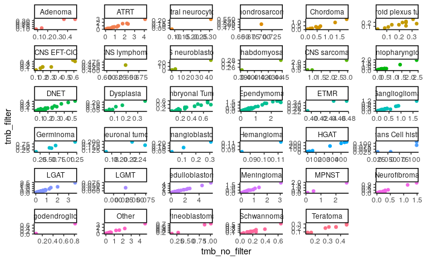

```r
pbta_cor_plot +
  ggplot2::facet_wrap(~short_histology, scales = "free")
```

Make the same plot for TCGA.

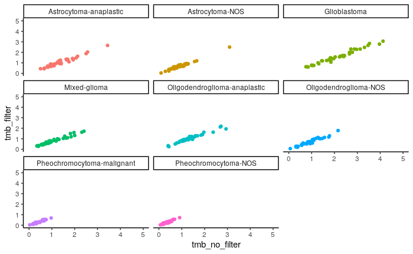

```r
tcga_cor_plot +
  ggplot2::facet_wrap(~short_histology)
```

## Does the filter affect the TCGA-PBTA comparison change?

Put PBTA and TCGA data into one long format data frame.

```r
all_data <- dplyr::bind_rows(list(tcga = tmb_tcga, pbta = tmb_pbta), .id = "dataset") %>%
  dplyr::select(tmb_filter, tmb_no_filter, dataset, Tumor_Sample_Barcode, short_histology) %>%
  tidyr::gather("filter", "tmb", -Tumor_Sample_Barcode, -dataset, -short_histology)
```

Plot the data overall.

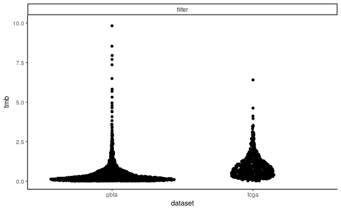

```r
ggplot2::ggplot(all_data, ggplot2::aes(x = dataset, y = tmb)) +
  ggforce::geom_sina() +
  ggplot2::theme_classic() +
  ggplot2::ylim(0, 10) +
  ggplot2::theme(legend.position = "none") +
  ggplot2::facet_wrap(~"filter")
```

## Plot the ratio of the nonfilter/filter tmb

We’ll plot this by `short_histology`.

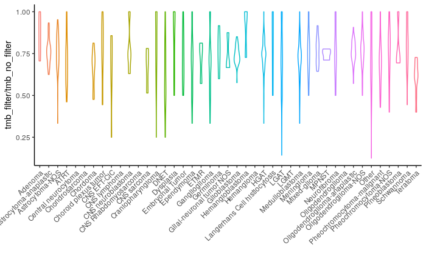

```r
all_data %>%
  tidyr::spread("filter","tmb") %>%
  dplyr::mutate(ratio = tmb_filter/tmb_no_filter) %>%
ggplot2::ggplot(ggplot2::aes(x = short_histology, y = ratio, color = short_histology)) +
  ggplot2::geom_violin() +
  ggplot2::theme_classic() +
  ggplot2::theme(axis.text.x = ggplot2::element_text(angle = 45, hjust = 1),
                 legend.position = "none") +
  ggplot2::xlab("") +
  ggplot2::ylab("tmb_filter/tmb_no_filter")
```

## Plot the TMB plot with no filter data

This code is directly copied from `tmb-compare-tcga/tmb-compare-tcga.Rmd`.

```r
pbta_plot <- cdf_plot(
  df = tmb_pbta_no_filter,
  plot_title = "PBTA",
  num_col = "tmb",
  group_col = "short_histology",
  color = "#3BC8A2",
  n_group = 5,
  x_lim = c(-1.2, 1.2),
  y_lim = c(0, 400),
  x_lab = "",
  y_lab = "Coding Mutations per Mb",
  breaks = c(0, 3, 10, 30, 100, 300)
) +
  ggplot2::theme(
    strip.text.x = ggplot2::element_text(size = 12),
    plot.margin = grid::unit(c(0.5, 0, 0.6, 0.5), "cm")
  )
```

```
the condition has length > 1 and only the first element will be used
```

```r
tcga_plot <- cdf_plot(
  df = tmb_tcga_no_filter,
  plot_title = "TCGA (Adult)",
  num_col = "tmb",
  group_col = "short_histology",
  color = "#630882",
  n_group = 5,
  x_lim = c(-1.2, 1.2),
  y_lim = c(0, 400),
  x_lab = "",
  y_lab = "Coding Mutations per Mb",
  breaks = c()
) +
  ggplot2::theme(
    axis.title.y = ggplot2::element_blank(),
    axis.text.y = ggplot2::element_blank(),
    axis.ticks.y = ggplot2::element_blank(),
    strip.text.x = ggplot2::element_text(size = 9),
    plot.margin = grid::unit(c(0.5, 1, 0.1, 0), "cm")
  )
```

```
the condition has length > 1 and only the first element will be used
```

```r
# Put the plots together
tmb_plot <- cowplot::plot_grid(pbta_plot, tcga_plot,
  align = "v",
  axis = "left",
  rel_widths = c(2.5, 1),
  label_size = 12
)
```

```
Removed 3 rows containing missing values (geom_point).Removed 1 rows containing missing values (geom_point).
```

```r
# Save the plot to a png
cowplot::save_plot(file.path("plots", "no_filter_tmb-cdf-pbta-tcga.png"),
  plot = tmb_plot, base_width = 35, base_height = 20, unit = "cm"
)
```

Print from png

### No filter TMB Plot

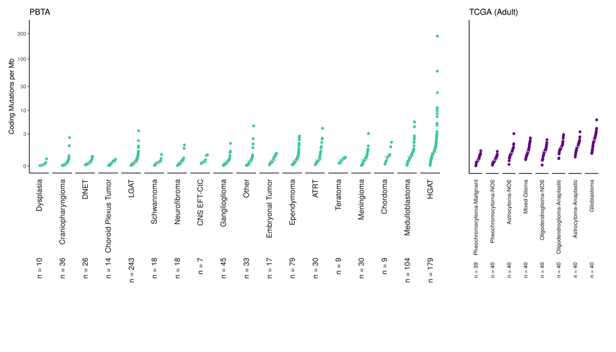

### With filter TMB Plot

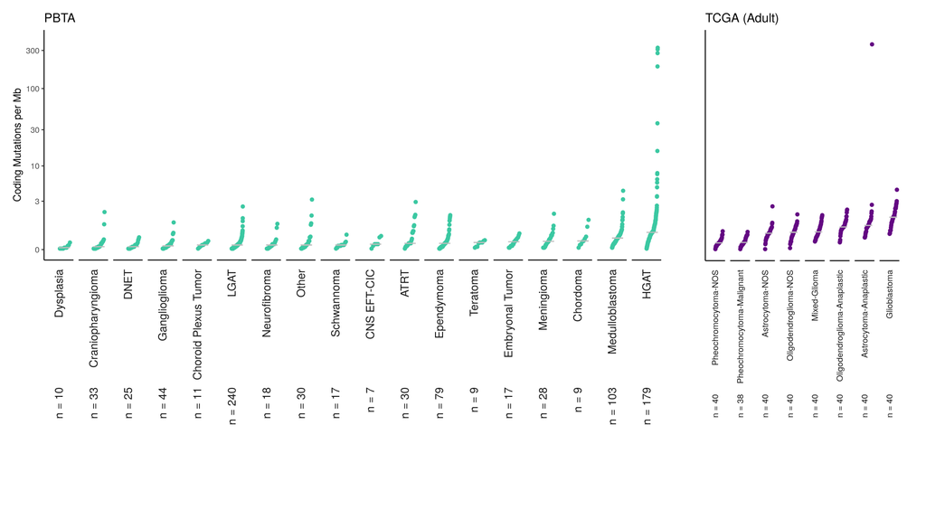